# Homework 1 Solutions

${\bf (1)}$ Define the following terms:

- **(a)** Population - the collection of all possible persons, events, or objects of interest
- **(b)** Sample - the subset of the population that we actually observe (the observed observations)
- **(c)** Parameter - A numerical characteristic of a population (alternatively: A function of the entire population)
- **(d)** Statistic - A numerical characteristic of a sample (alternatively: A function of the sample)

${\bf (2)}$ Explain the difference between a **qualitative** (categorical) and a **quantitative** variable

A qualitative variable is a non-numeric characteristic such as a name or label while a quantitative variable is numerical characteristic such as a measurement or count

${\bf (3)}$ Explain the difference between a **discrete** and a **continuous** variable and give an example of each

A discrete variable is a quantitative variable that takes on only distinct whole number (integer) values such as counts whereas a continuous variable is a quantitative variable that can assume any value within a certain interval such temperature or height

${\bf (4)}$ Explain the difference between a **nominal** and an **ordinal** variable and give an example of each

A nominal variable is a qualitative variable that has categories with no inherent ordering such as the names of a city or the brands or shoes. An ordinal variable is a qualitative variable that has an inherent ordering to its categories such as a Likert score or education level.

${\bf (5)}$ **At What age did women marry?** A historian wants to estimate the average age at marriage of women in New England in the early 19th century. Within her state archives, she finds marriage records for the years $1800 - 1820$, which she treats as a sample of all marriage records from the early 19th century. The average age of the women in the records is $24.1$ years of age. Using the appropriate statistical method, she estimates that the average age of brides in the early $19^{th}$- century New England was between $23.5$ and $24.7$ years of age.

${\bf (6)}$ Consider the following data obtained from flipping a coin 15 times. A value of $H$ denotes the coin was heads whereas a value of $T$ denotes the coin flip was tails.

| coin.flip.result. | H | H | H | T | H | T | T | T | H | H | T | T | T | H | T |
| --- | --- | --- | --- | --- | --- | --- | --- | --- | --- | --- | --- | --- | --- | --- | --- |

Compute the frequency table for the variable ``coin flip result” and answer the following questions:

| Result | Frequency | Relative Frequency |
| --- | --- | --- |
| H | 7 | 7/15 = 0.47 |
| T | 8 | 8/15 = 0.53 |

- **(a)** What type of variable is ``Coin Flip Result”? Qualitative nominal variable
- **(b)** What proportion of the coin flips were heads? $0.47$ or $47\%$
- **(c)** Why do we not compute the cumulative relative frequency for this variable? The variable is nominal and therefore has no inherent ordering for summing up the relative frequencies
- **(d)** What the best graphical display for this variable and why? Since there are only two categories (heads or tails) a pie chart or bar graph would be sufficient to show the distribution

${\bf (7)}$ A survey about color preferences reported the age distribution of the people who responded. Below are the results

| Age Group (Years) | 1-18 | 19-24 | 25-25 | 36-60 | 51-69 | 70 and over |
| --- | --- | --- | --- | --- | --- | --- |
| Counts | 10 | 97 | 70 | 36 | 14 | 5 |
| Relative Frequency | 0.04 | 0.42 | 0.30 | 0.16 | 0.06 | 0.02 |

Use this table to answer parts a - d

- **(a)** Compute the relative frequency for each age group
- **(b)** Make a bar graph where the heights of the bars are relative frequencies

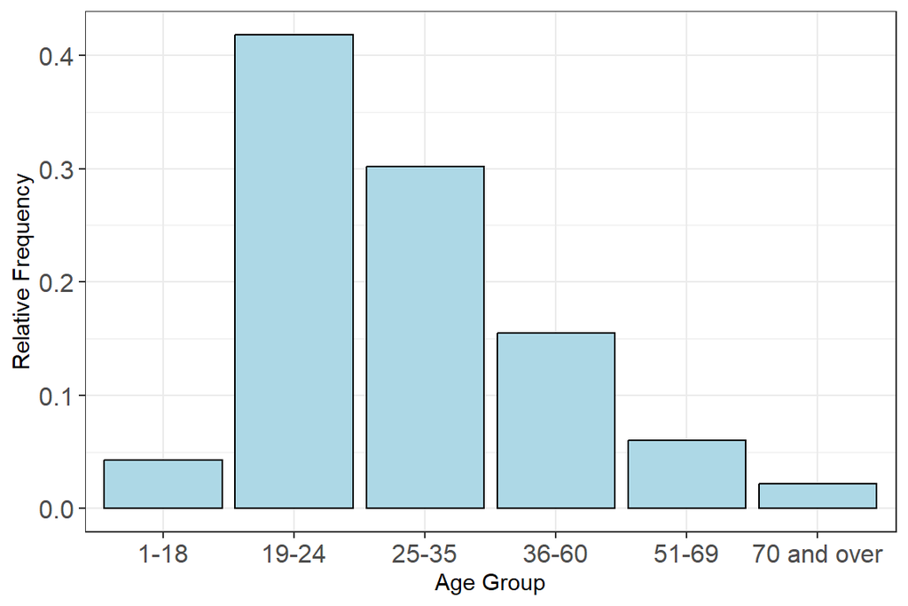

- **(c)** Describe the distribution the distribution is slightly right skew indicating that most respondants were between 19 and 35 years of age
- **(d)** Explain why your bar graph is not a histogram A histogram has intervals of equal length

${\bf (8)}$ Email spam is the curse of the internet. The table below gives a compilation of the most common types of spam

| Type of Spam | Percentage |
| --- | --- |
| Adult | 14.5 |
| Financial | 16.2 |
| Health | 7.3 |
| Leisure | 7.8 |
| Products | 21.0 |
| Scams | 14.2 |

Use the table to answer the questions a and b

- **(a)** Report the modal spam category The modal category is “Products” because it has the highest frequency
- **(b)** Construct a **Pareto chart** using the table above

[figure not shown]

${\bf (9)}$ A farmer in Idaho is interested in the number of rainy days in a given year so he records the number of rainy $R$, cloudy $C$ and sunny $S$ days over two weeks in $May$. His observations are
$$\{R,R,C,C,C,S,S,C,R,R,C,R,S,S\}$$
. Use the farmers observations to answer the following questions.

- **(a)** Based on the farmers observations, what proportion of days were rainy?
  $$\hat{p}_{\text{rainy}} = \frac{5}{14} =
  0.36$$
- **(b)** Is the proportion in part **(a)** a statistic or a parameter? why? It is a statistic because it was computed from a sample of 14 observations of the weather
- **(c)** What population is the farmer studying? is it a finite or infinite population? The population is all 365 days in a given year. It is finite

${\bf (10)}$ Consider the following data from a survey conducted on college students in the state of Florida. As part of their research, surveyors recorded the high school performance (measured in grade point average - GPA) of 35 college students from across the state. For your convenience the data have been sorted from least to greatest:

$$2.0, 2.1, 2.3, 2.8, 3.0, 3.0, 3.0, 3.0,
3.0, 3.0,$$
$$3.0, 3.0, 3.0, 3.1, 3.2,
3.3, 3.3, 3.4, 3.4, 3.4,$$
$$3.4,
3.5, 3.5, 3.5, 3.5, 3.6, 3.6, 3.7, 3.7, 3.8,$$
$$3.8, 3.8, 3.8, 4.0, 4.0$$

The following frequency table gives the distribution of the variable high school GPA (with values rounded to nearest 0.5). Fill in the table and answer the following questions:

| GPA | Frequency | Relative frequency | Cumulative RF |
| --- | --- | --- | --- |
| 2.0 | 2 | 0.06 | 0.06 |
| 2.5 | 1 | 0.03 | 0.09 |
| 3.0 | 12 | 0.34 | 0.43 |
| 3.5 | 14 | 0.40 | 0.83 |
| 4.0 | 6 | 0.17 | 1.00 |

- **(a)** What type of variable is GPA? Quantitative continuous
- **(b)** What proportion of college students had a high school GPA $> 3.0$? 0.57
- **(c)** What proportion of college students had a high school GPA $< 3.0$? 0.09
- **(d)** What is the **mean** GPA in this sample?
  $$\bar{x} =
  \frac{2.0+2.1+...+4.0+4.0}{35} = \frac{2(2)+1(2.5)+...+6(4)}{35} =
  3.3$$
- **(e)** What is the **median** GPA in this sample? median $= 3.4$
- **(f)** What is the **mode** of GPA in this sample?

Using the frequency table on the rounded values the mode is the value with the highest relative frequency $ = 3.5$

(Using the raw data) the mode is the most frequent value observed in the data which is $3.0$

- **(g)** Construct a dot plot for the variable GPA (hint use the frequency table)

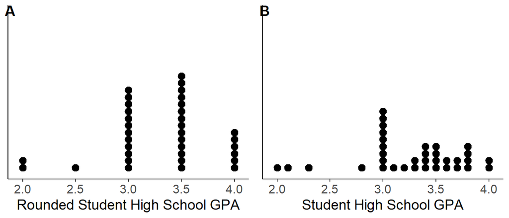

  1. Dot plot using the rounded GPA values from the frequency table (B) Dot plot using the raw GPA values
- **(h)** Construct a histogram for the variable GPA (hint use the frequency table)

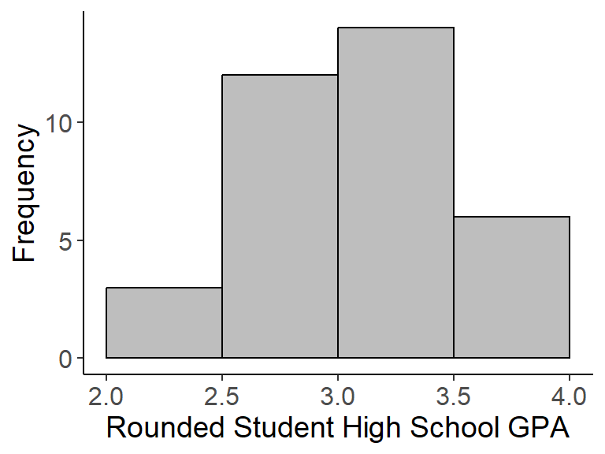

  1. Histogram using the rounded GPA values (e.g 4 total bins) from the frequency table
- **(i)** Construct a stem and leaf plot for the variable GPA

```
## [1] "Using the Rounded GPA scores:"
```

```
##
##   The decimal point is 1 digit(s) to the left of the |
##
##   20 | 00
##   22 |
##   24 | 0
##   26 |
##   28 |
##   30 | 000000000000
##   32 |
##   34 | 00000000000000
##   36 |
##   38 |
##   40 | 000000
##
## NULL
```

```
## [1] "Using the Raw Data:"
```

```
##
##   The decimal point is 1 digit(s) to the left of the |
##
##   20 | 0
##   21 | 0
##   22 |
##   23 | 0
##   24 |
##   25 |
##   26 |
##   27 |
##   28 | 0
##   29 |
##   30 | 000000000
##   31 | 0
##   32 | 0
##   33 | 00
##   34 | 0000
##   35 | 0000
##   36 | 00
##   37 | 00
##   38 | 0000
##   39 |
##   40 | 00
##
## NULL
```

${\bf (11)}$ Which statistic is more resistant to outliers, the mean or median? Why?

The median is resistant to outliers because it relies on only the middle value (or middle two values if $n$ is even). Therefore, how far a value is from the center does not influence the median. The mean, however, is computed using values in a sample distribution. This causes the mean to be pulled in the direction of extreme values.

${\bf (12)}$ Describe the shape of the following distributions and for each distribution identify if the mean will be larger, smaller or the same as the median.

**(a)** Skew right. The mean will be greater than median because the center of the data is pulled toward the right side of the distribution

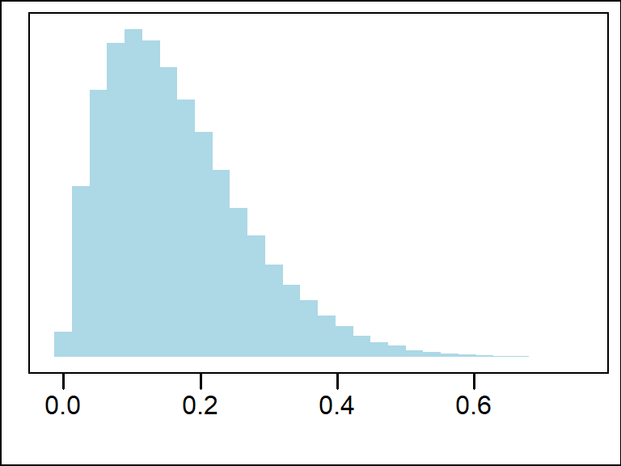

**(b)**  
Symmetric/Bell shaped. The mean and the median will be equal

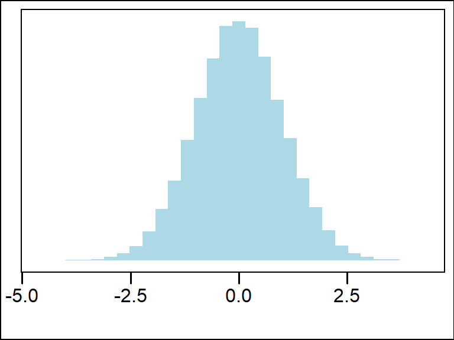

**(c)**  
Skew left. The mean will be less than median because the center of the data is pulled toward the left side of the distribution

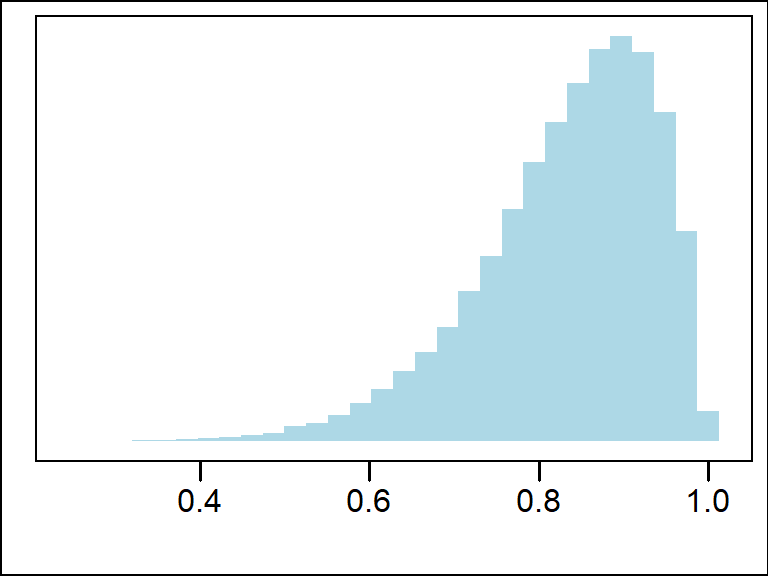

${\bf (13)}$ Consider the following four sets of observations of a quantitative variable $x$. For your convenience the observations have been sorted in increasing order. Match datasets $1-4$ with the correct histogram (labeled $A - D$)

$$\text{Dataset 1} = \{0.1, 1.1, 2.6, 2.7,
3.4, 3.4, 4.1, 4.4, 8.8, 9.6\}$$
$$\text{Dataset 2}= \{0.1, 0.3, 1.2, 2.4, 4.4, 4.5,
8.0, 8.9, 9.3, 9.3\}$$
$$\text{Dataset
3} = \{1.1, 3.8, 5.3, 6.0, 6.2, 6.9, 7.9, 7.9, 8.1, 8.7\}$$
$$\text{Dataset 4} = \{3.4, 4.5, 5.4, 5.6, 7.0,
8.5, 8.9, 9.2, 9.7, 9.7\}$$

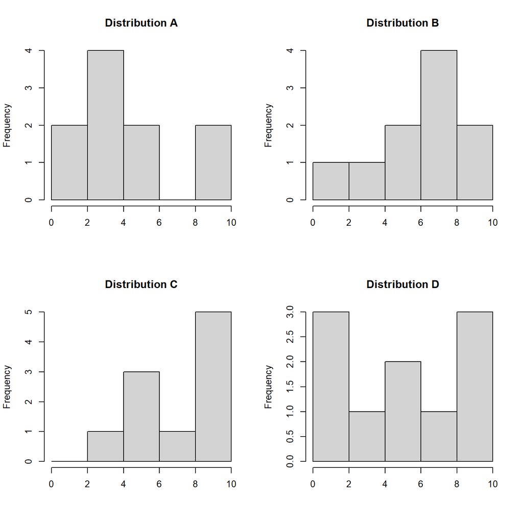

- Dataset 1 goes with histogram A
- Dataset 2 goes with histogram D
- Dataset 3 goes with histogram B
- Dataset 4 goes with histogram C

${\bf (14)}$ Consider the following set of 10 observations of a variable $X$ sorted from least to greatest:
$$3.3, 3.8, 4.0, 4.8, 4.8, 5.1, 5.2, 5.6, 5.7,
6.9$$
Use the data to answer parts a-b

- **(a)** Given the data, compute the $50^{th}$ percentile of $X$
  $$\frac{4.8+5.1}{2} = 4.95$$
- **(b)** Compute Interquartile Range (IQR) range of $X$
  $$IQR = 5.6 - 4.0 = 1.6$$

${\bf (15)}$ Consider the following $n = 20$ observations of the sugar and sodium content of several popular cereal brands and answer questions a - g:

| Brand | Sodium (mg) | Sugar (g) | Type |
| --- | --- | --- | --- |
| Frosted Mini Wheats | 0 | 11 | A |
| Raisin Bran | 340 | 18 | A |
| All Bran | 70 | 5 | A |
| Apple Jacks | 140 | 14 | C |
| Cap’n Crunch | 200 | 12 | C |
| Cheerios | 180 | 1 | C |
| Cinnamon Toast Crunch | 210 | 10 | C |
| Crackling Oat Bran | 150 | 16 | A |
| Fiber One | 100 | 0 | A |
| Frosted Flakes | 130 | 12 | C |
| Froot Loops | 140 | 14 | C |
| Honey Bunches of Oats | 180 | 7 | A |
| Honey Nut Cheerios | 190 | 9 | C |
| Life | 160 | 6 | C |
| Rice Krispies | 290 | 3 | C |
| Honey Smacks | 50 | 15 | A |
| Special K | 220 | 4 | A |
| Wheaties | 180 | 4 | A |
| Corn Flakes | 200 | 3 | A |
| Honeycomb | 210 | 11 | C |

- **(a)** Construct a histogram of the data using the following bins: $\leq 2 (g)$, $2 - 4 (g)$, $4 - 6 (g)$, $6 - 8 (g)$,$8 - 10 (g)$, $10 - 12 (g)$, $12 - 14 (g)$,$14 - 16 (g)$,$> 16 (g)$ (hint start by creating a frequency table)

[figure not shown]

Frequency table used to construct histogram for the variable “Sugar (g)”

| Sugar (g) | Frequency | RF(x) | CRF(x) |
| --- | --- | --- | --- |
| < = 2 (g) | 2 | 0.10 | 0.10 |
| 2 - 4 (g) | 4 | 0.20 | 0.30 |
| 4 - 6 (g) | 2 | 0.10 | 0.40 |
| 6 - 8 (g) | 1 | 0.05 | 0.45 |
| 8 - 10 (g) | 2 | 0.10 | 0.55 |
| 10 - 12 (g) | 4 | 0.20 | 0.75 |
| 12 - 14 (g) | 2 | 0.10 | 0.85 |
| 14 - 16 (g) | 2 | 0.10 | 0.95 |
| > 16 (g) | 1 | 0.05 | 1.00 |

- **(b)** Compute the mean, median, and mode of the variable ``Sugar (g)” Using the raw data there are 5 modes each with a frequency of 2 mode(s) $= 3,4,11,12,14$ median $= \frac{9+10}{2} = 9.5$
  $$\bar{x} = \frac{1}{20}\sum_{i=1}^{20} x_i =
  \frac{(11+18+5+14+...+3+11)}{20} = 8.75$$
  (note that the mean may be slightly different if you used the frequency table above
- **(c)** Compute the variance and standard deviation of the variable ``Sugar (g)”
  $$s^2 = \frac{1}{19}\sum_{i=1}^{19} (x-\bar{x})^2 =
  \frac{(11 - 8.75)^2 + (18-8.75)^2 + ...+(3-8.75)^2 + (11 -
  8.75)^2}{19}$$
  $$= \frac{5.06 + 85.56
  + ...+33.06+5.06}{19} = 28.3$$
  $$s =
  \sqrt{s^2} = \sqrt{28.3} = 5.32$$
- **(d)** Compute the quartiles (Q1, Q2, Q3) and interquartile range of the variable ``Sugar (g)”
  $$Q1 = 4, \ Q2 =
  \text{median} = 9.5, \ Q3 = 13, \ IQR = 13 - 4 =
  9$$
- **(e)** Create a box and whisker plot for the variable ``Sugar (g)” and mark the Q1, Q2, and Q3 quartiles, the median and any potential outliers

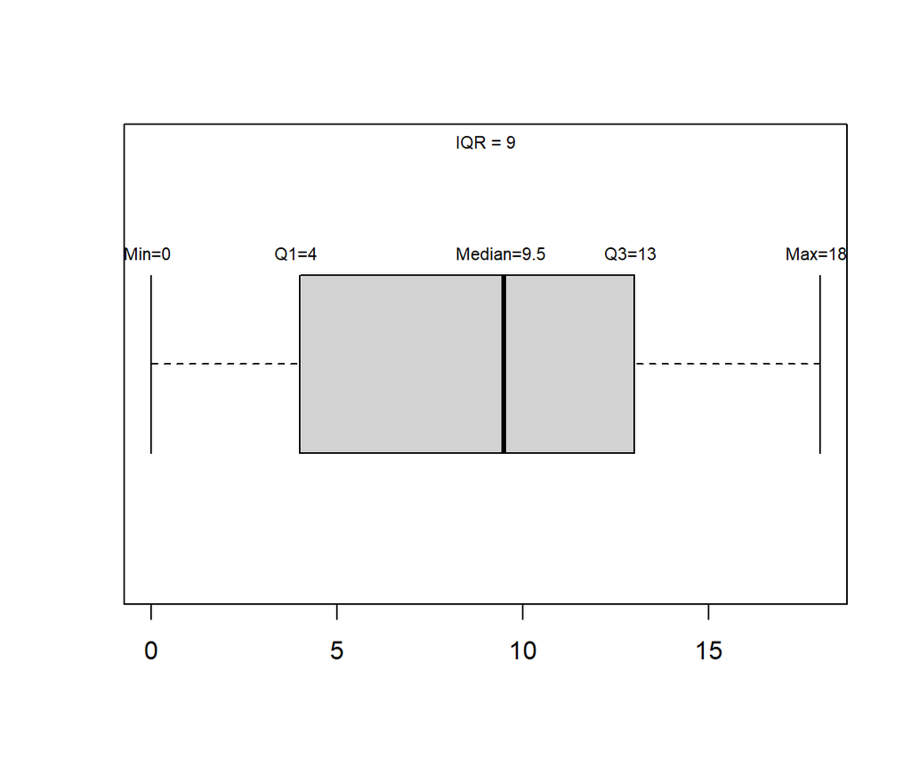

Boxplot of Sugar content in 20 cereal brands

- **(f)** Plot the Cumulative Distribution of the variable ``Sugar (g)”

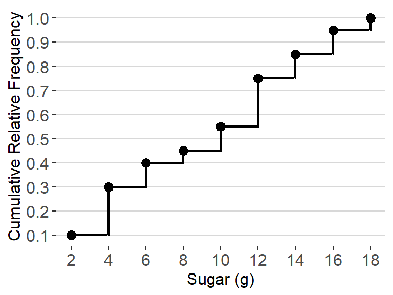

Cumulative Distribution of Sugar (g)

- **(g)** What proportion of cereals have a sugar content less than or equal to 10 grams?
  $$55\%$$